# Session 9: Scraping Interactive Web Pages

Introduction to Web Scraping and Data Management for Social Scientists

Johannes B. Gruber

2026-07-30

# Introduction

## This Course

| Day | Session |
| --- | --- |
| 1 | Introduction |
| 2 | Data Structures and Wrangling |
| 3 | Working with Files |
| 4 | Linking and joining data & SQL |
| 5 | Database Software and Scaling your Analyses |
| 6 | Introduction to the Web |
| 7 | Static Web Pages |
| 8 | Application Programming Interface (APIs) |
| 9 | Interactive Web Pages |
| 10 | Building a Reproducible Research Project |

## The Plan for Today

In this session, we learn how to hunt down **wild** data. We will:

- Learn how to find secret APIs
- Emulate a Browser
- We focus specifically on step 1 below

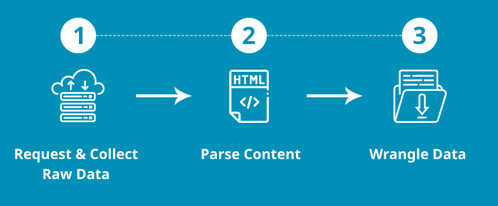

Original Image Source: prowebscraper.com

[figure not shown]

[Philipp Pilz](https://unsplash.com/@buchstabenhausen) via unsplash.com

# Request & Collect Raw Data: a closer look

## Common Problems

Imagine you wanted to scrape researchgate.net, since it contains self-created profiles of many researchers. However, when you try to get the html content:

```r
library(rvest)
read_html("https://www.researchgate.net/profile/Johannes-Gruber-2")
```

```
Error in `open.connection()`:
! cannot open the connection
```

If you don’t know what an HTTP error means, you can go to https://http.cat and have the status explained in a fun way. Below I use a little convenience function:

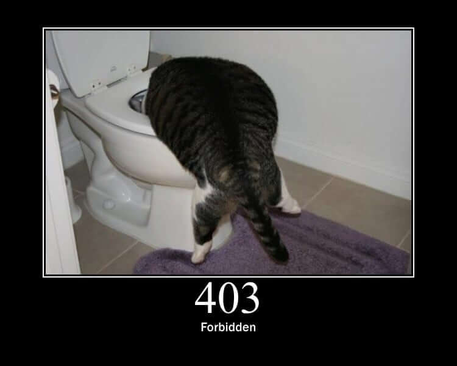

```r
error_cat <- function(error) {
  link <- paste0("https://http.cat/images/", error, ".jpg")
  knitr::include_graphics(link)
}
error_cat(403)
```

## So what’s going on?

- If something like this happens, the server essentially did not fullfill our request
- This is because the website seems to have some special requirements for serving the (correct) content. These could be:
  - specific user agents
  - other specific headers
  - login through browser cookies
- To find out how the browser manages to get the correct response, we can use the Network tab in the inspection tool

## Strategy 1: Emulate what the Browser is Doing

Open the Inspect Window Again:

[figure not shown]

## Strategy 1: Emulate what the Browser is Doing

But this time, we focus on the *Network* tab:

[figure not shown]

Here we get an overview of all the network activity of the browser and the individual requests for data that are performed. Clear the network log first and reload the page to see what is going on. Finding the right call is not always easy, but in most cases, we want:

- a call with status 200 (OK/successful)
- a document type
- something that is at least a few kB in size
- *Initiator* is usually “other” (we initiated the call by refreshing)

When you identified the call, you can right click -> copy -> copy as cURL

## Refresher: `cURL` Calls

What is `cURL`:

- `cURL` is a library that can make HTTP requests.
- it is widely used for API calls from the terminal.
- it lists the parameters of a call in a pretty readable manner:
  - the unnamed argument in the beginning is the Uniform Resource Locator (URL) the request goes to
  - `-H` arguments describe the headers, which are arguments sent with the call
  - `-d` is the data or body of a request, which is used e.g., for uploading things
  - `-o`/`-O` can be used to write the response to a file (otherwise the response is returned to the screen)
  - `--compressed` means to ask for a compressed response which is unpacked locally (saves bandwith)

```bash
curl 'https://www.researchgate.net/profile/Johannes-Gruber-2' \
  -H 'authority: www.researchgate.net' \
  -H 'accept: text/html,application/xhtml+xml,application/xml;q=0.9,image/avif,image/webp,image/apng,*/*;q=0.8,application/signed-exchange;v=b3;q=0.7' \
  -H 'accept-language: en-GB,en;q=0.9' \
  -H 'cache-control: max-age=0' \
  -H '[Redacted]' \
  -H 'sec-ch-ua: "Chromium";v="115", "Not/A)Brand";v="99"' \
  -H 'sec-ch-ua-mobile: ?0' \
  -H 'sec-ch-ua-platform: "Linux"' \
  -H 'sec-fetch-dest: document' \
  -H 'sec-fetch-mode: navigate' \
  -H 'sec-fetch-site: cross-site' \
  -H 'sec-fetch-user: ?1' \
  -H 'upgrade-insecure-requests: 1' \
  -H 'user-agent: Mozilla/5.0 (X11; Linux x86_64) AppleWebKit/537.36 (KHTML, like Gecko) Chrome/115.0.0.0 Safari/537.36' \
  --compressed
```

## `httr2::curl_translate()`

- We have seen `httr2::curl_translate()` in action yesterday (and the alternative https://curlconverter.com/r-httr2/)
- It can also convert more complicated API calls that make look `R` no different from a regular browser
- (Remember: you need to escape all `"` in the call, press `ctrl` + `F` to open the Find & Replace tool and put `"` in the find `\"` in the replace field and go through all matches except the first and last):

```r
library(httr2)
httr2::curl_translate(
  "curl 'https://www.researchgate.net/profile/Johannes-Gruber-2' \
  -H 'authority: www.researchgate.net' \
  -H 'accept: text/html,application/xhtml+xml,application/xml;q=0.9,image/avif,image/webp,image/apng,*/*;q=0.8,application/signed-exchange;v=b3;q=0.7' \
  -H 'accept-language: en-GB,en;q=0.9' \
  -H 'cache-control: max-age=0' \
  -H 'cookie: [Redacted]' \
  -H 'sec-ch-ua: \"Chromium\";v=\"115\", \"Not/A)Brand\";v=\"99\"' \
  -H 'sec-ch-ua-mobile: ?0' \
  -H 'sec-ch-ua-platform: \"Linux\"' \
  -H 'sec-fetch-dest: document' \
  -H 'sec-fetch-mode: navigate' \
  -H 'sec-fetch-site: cross-site' \
  -H 'sec-fetch-user: ?1' \
  -H 'upgrade-insecure-requests: 1' \
  -H 'user-agent: Mozilla/5.0 (X11; Linux x86_64) AppleWebKit/537.36 (KHTML, like Gecko) Chrome/115.0.0.0 Safari/537.36' \
  --compressed"
)
```

```
request("https://www.researchgate.net/profile/Johannes-Gruber-2") |>
  req_cookies_set(
    `[Redacted]` = "",
  ) |>
  req_headers(
    authority = "www.researchgate.net",
    accept = "text/html,application/xhtml+xml,application/xml;q=0.9,image/avif,image/webp,image/apng,*/*;q=0.8,application/signed-exchange;v=b3;q=0.7",
    `accept-language` = "en-GB,en;q=0.9",
    `cache-control` = "max-age=0",
    cookie = "[Redacted]",
    `upgrade-insecure-requests` = "1",
    `user-agent` = "Mozilla/5.0 (X11; Linux x86_64) AppleWebKit/537.36 (KHTML, like Gecko) Chrome/115.0.0.0 Safari/537.36",
  ) |>
  req_perform()
```

## ‘Emulating’ the Browser Request

```r
resp <- request("https://www.researchgate.net/profile/Johannes-Gruber-2") |>
  req_headers(
    authority = "www.researchgate.net",
    accept = "text/html,application/xhtml+xml,application/xml;q=0.9,image/avif,image/webp,image/apng,*/*;q=0.8,application/signed-exchange;v=b3;q=0.7",
    `accept-language` = "en-GB,en;q=0.9",
    `cache-control` = "max-age=0",
    cookie = "[Redacted]",
    `sec-ch-ua` = "\"Chromium\";v=115\", \"Not/A)Brand\";v=\"99",
    `sec-ch-ua-mobile` = "?0",
    `sec-ch-ua-platform` = "\"Linux\"",
    `sec-fetch-dest` = "document",
    `sec-fetch-mode` = "navigate",
    `sec-fetch-site` = "cross-site",
    `sec-fetch-user` = "?1",
    `upgrade-insecure-requests` = "1",
    `user-agent` = "Mozilla/5.0 (X11; Linux x86_64) AppleWebKit/537.36 (KHTML, like Gecko) Chrome/115.0.0.0 Safari/537.36",
  ) |>
  req_perform()
resp
```

```
<httr2_response>
GET https://www.researchgate.net/profile/Johannes-Gruber-2
Status: 200 OK
Content-Type: text/html
Body: In memory (326535 bytes)
```

[figure not shown]

## Mission outcome: success

- the result can be converted into an `rvest` object and parsed

```r
resp |>
  resp_body_html() |>
  html_elements("[data-testid=\"publicProfileStatsCitations\"]") |>
  html_text()
```

```
[1] "269"
```

# Example: anyflip

## Goal

- get information stored as “flipping book”
- don’t take individual screenshots/pages, but get whole book

[figure not shown]

## Scout

- hovering over the page, we find this element

  ```html
  <div class="side-image"   style="position:absolute;z-index:0;width:100%;height:100%;top:0;lef  t:0;">
    <img id="c7ARbTjMdA" alt="c7ARbTjMdA"   src="../files/large/ae105d2ec767250c5e9a4e2b0a48efaf.webp?174011361  2" style="pointer-events: none; width: 100%; height: 100%;   position: absolute; top: 0px; left: 0px; transform-origin: 0% 0%   0px; transform: scale(1);" width="100%" height="100%">
  </div>
  ```

- looks easy enough! `.side-image img` should give us the link!
- hold down `ctrl` and click on the link in the inspect

[figure not shown]

## Scout

Can we get the actual file?

```r
dir.create("data/anyflip", showWarnings = FALSE)
out_file <- paste0("data/anyflip/1_ae105d2ec767250c5e9a4e2b0a48efaf.webp")
curl::curl_download(
  url = "https://online.anyflip.com/ogboc/rozd/files/large/ae105d2ec767250c5e9a4e2b0a48efaf.webp?1740113612",
  destfile = out_file
)
file.size(out_file)
```

```
[1] 166322
```

We can!

[figure not shown]

## Okay, so where are the rest of the links?

```r
read_html("https://anyflip.com/ogboc/rozd/") |>
  html_elements(".side-image img")
```

```
{xml_nodeset (0)}
```

😫😫😫

- checking the URL that `rvest` gets
- then the actual source code in the browser
- result: they have an empty iframe where the image should be

## So where do the image links come from?

How I got here:

1. open network tab
2. tap search
3. look for a known value `ae105d2ec767250c5e9a4e2b0a48efaf.webp`
4. copy URL

[figure not shown]

## Get image links

```r
book_config <- read_html(
  "https://online.anyflip.com/ogboc/rozd/mobile/javascript/config.js"
) |>
  as.character() |>
  str_extract("\\{.*\\}") |>
  jsonlite::fromJSON()
lobstr::tree(book_config, max_depth = 1)
```

```
<list>
├─bookConfig: "v0100011028ecMZq4MXsuIVu2OXo0Bfl..."
├─aliasConfig: <list>...
├─aliasLanguage: <list>...
├─meta: <list>...
├─project-config: <list>
├─bmtConfig: <list>...
├─videoList: <list>
├─staticAd: <list>
│ └─haveAd: FALSE
├─language: S3<data.frame>...
├─ols: <list>
├─slideshow: <list>
├─pageEditor: <list>
├─flipByAudio: <list>
├─downloadconfig: <NULL>
├─assistantConfig: <NULL>
├─phoneNumber: <list>
├─bookPlugin: <list>
├─isCover: 1
├─fliphtml5_pages: S3<data.frame>...
├─downloadConfig: <NULL>
└─loadingConfig: <list>...
```

```r
file_names <- book_config |>
  pluck("fliphtml5_pages", "n") |>
  unlist()
file_names
```

```
  [1] "ae105d2ec767250c5e9a4e2b0a48efaf.webp"
  [2] "ca317b05c3eeca7309063ce966b4b933.webp"
  [3] "7d3c72c5f99bd90aa0488e3ed30eba6b.webp"
  [4] "6843a01460fcbaf5a7c602619de9bf79.webp"
  [5] "5f97face70b3844c7c31b178689a4608.webp"
  [6] "ca1eec333b572f456a860a889c999663.webp"
  [7] "6aaadf36dc0b300be7a23d0f01007d41.webp"
  [8] "b66977bb620f6da6cc9f58f6a6678bd8.webp"
  [9] "e5e27a44fbcc402d664458523b729ab6.webp"
 [10] "8224cf93326e26deb050723f496daaa5.webp"
 [11] "ea2a3455c0dd8d5f3a03a0201eeffd2f.webp"
 [12] "25cda93a37c98d7546642e6c4622c3ce.webp"
 [13] "a653f7384fe123d3bd503e91bbb0e50d.webp"
 [14] "8dd60a91f27759067434afc91ec2ee6f.webp"
 [15] "1a58dce6c1f6f44c7c306acbb204cc6c.webp"
```

[output cut: 121 more lines]

## get images

```r
dl_urls <- paste0(
  "https://online.anyflip.com/ogboc/rozd/files/large/",
  file_names
)
out_files <- paste0(
  "data/anyflip/",
  sprintf("%03d", seq_along(file_names)),
  "_",
  file_names
)
curl::multi_download(
  dl_urls,
  out_files
)
```

```
# A tibble: 136 × 10
   success status_code resumefrom url   destfile error type  modified
   <lgl>         <dbl>      <dbl> <chr> <chr>    <chr> <chr> <dttm>
 1 TRUE            200          0 http… /home/j… <NA>  imag… 2025-02-21 05:53:27
 2 TRUE            200          0 http… /home/j… <NA>  imag… 2025-02-21 05:53:27
 3 TRUE            200          0 http… /home/j… <NA>  imag… 2025-02-21 05:53:27
 4 TRUE            200          0 http… /home/j… <NA>  imag… 2025-02-21 05:53:27
 5 TRUE            200          0 http… /home/j… <NA>  imag… 2025-02-21 05:53:27
 6 TRUE            200          0 http… /home/j… <NA>  imag… 2025-02-21 05:53:27
 7 TRUE            200          0 http… /home/j… <NA>  imag… 2025-02-21 05:53:27
 8 TRUE            200          0 http… /home/j… <NA>  imag… 2025-02-21 05:53:27
 9 TRUE            200          0 http… /home/j… <NA>  imag… 2025-02-21 05:53:27
10 TRUE            200          0 http… /home/j… <NA>  imag… 2025-02-21 05:53:27
# ℹ 126 more rows
# ℹ 2 more variables: time <dbl>, headers <list>
```

## Finally: get a single PDF

```r
# convert each image to a pdf
for (page in out_files) {
  magick::image_read(page) |>
    magick::image_write(path = paste0(page, ".pdf"), format = "pdf")
}

# combine into one pdf
title <- read_html("https://anyflip.com/ogboc/rozd/") |>
  html_elements("title") |>
  html_text2() |>
  janitor::make_clean_names()

pdftools::pdf_combine(
  input = paste0(out_files, ".pdf"),
  output = paste0("data/anyflip/", title, ".pdf")
)
```

```
[1] "/home/johannes/Dropbox/Teaching/ess-web-scraping-data-management/09_Interactive_Web_Pages/data/anyflip/rayngan_sthankarn_thang_sangkhm_ssw_11_pi_2567_tpso_11_flip_pdf_any_flip.pdf"
```

## Mission outcome: success!

To summarise the steps:

1. poking around the website with the inspect tool
2. found an image link that we could download
3. the link was not actually in the HTML source, but must come from somewhere
4. found the request that loads the ‘config’ JSON, containing all the image names in order
5. guessed the format of the image links from the one link we got + the image names
6. Downloaded the files -> success!

[figure not shown]

## Extra: getting the text data?

- since this is a pdf that was made from combining images, we have **no actual text data**
- we can use Optical Character Recognition (and early version of visual ML models)

```r
pdftools::pdf_ocr_text(
  "data/anyflip/002_ca317b05c3eeca7309063ce966b4b933.webp.pdf",
  language = "tha"
)
```

```
Converting page 1 to 002_ca317b05c3eeca7309063ce966b4b933.webp_1.png... done!
```

```
[1] "ค ํ า น ํ า\n\nส ํ า น ั ก ง า น ป ล ั ด ก ร ะ ท ร ว ง ก า ร พ ั ฒ น า ส ั ง ค ม แล ะ ค ว า ม ม ั น ค ง ขอ ง ม น ุ ษ ย ์ ได ้ ม อ บ ห ม า ย ให ้\nส ํ า น ั ก ง า น ส ่ ง เส ร ิ ม แล ะ ส น ั บ ส น ุ น ว ิ ชา ก า ร 1-11 (ส ส ว . 1-11) ด ํ า เน ิ น ก า ร โค ร ง ก า ร จ ั ด ท ํ า ร า ย ง า น ส ถา น…
```